# **Problem Statement**

#### **Business Context**

Understanding customer personality and behavior is pivotal for businesses to enhance customer satisfaction and increase revenue. Segmentation based on a customer's personality, demographics, and purchasing behavior allows companies to create tailored marketing campaigns, improve customer retention, and optimize product offerings.

A leading retail company with a rapidly growing customer base seeks to gain deeper insights into their customers' profiles. The company recognizes that understanding customer personalities, lifestyles, and purchasing habits can unlock significant opportunities for personalizing marketing strategies and creating loyalty programs. These insights can help address critical business challenges, such as improving the effectiveness of marketing campaigns, identifying high-value customer groups, and fostering long-term relationships with customers.

With the competition intensifying in the retail space, moving away from generic strategies to more targeted and personalized approaches is essential for sustaining a competitive edge.

#### **Objective**

In an effort to optimize marketing efficiency and enhance customer experience, the company has embarked on a mission to identify distinct customer segments. By understanding the characteristics, preferences, and behaviors of each group, the company aims to:

1. Develop personalized marketing campaigns to increase conversion rates.
2. Create effective retention strategies for high-value customers.
3. Optimize resource allocation, such as inventory management, pricing strategies, and store layouts.

As a data scientist tasked with this project, your responsibility is to analyze the given customer data, apply machine learning techniques to segment the customer base, and provide actionable insights into the characteristics of each segment.

#### **Data Dictionary**

The dataset includes historical data on customer demographics, personality traits, and purchasing behaviors. Key attributes are:

1. **Customer Information**
   - **ID:** Unique identifier for each customer.
   - **Year_Birth:** Customer's year of birth.
   - **Education:** Education level of the customer.
   - **Marital_Status:** Marital status of the customer.
   - **Income:** Yearly household income (in dollars).
   - **Kidhome:** Number of children in the household.
   - **Teenhome:** Number of teenagers in the household.
   - **Dt_Customer:** Date when the customer enrolled with the company.
   - **Recency:** Number of days since the customer’s last purchase.
   - **Complain:** Whether the customer complained in the last 2 years (1 for yes, 0 for no).
2. **Spending Information (Last 2 Years)**
   - **MntWines:** Amount spent on wine.
   - **MntFruits:** Amount spent on fruits.
   - **MntMeatProducts:** Amount spent on meat.
   - **MntFishProducts:** Amount spent on fish.
   - **MntSweetProducts:** Amount spent on sweets.
   - **MntGoldProds:** Amount spent on gold products.
3. **Purchase and Campaign Interaction**
   - **NumDealsPurchases:** Number of purchases made using a discount.
   - **AcceptedCmp1:** Response to the 1st campaign (1 for yes, 0 for no).
   - **AcceptedCmp2:** Response to the 2nd campaign (1 for yes, 0 for no).
   - **AcceptedCmp3:** Response to the 3rd campaign (1 for yes, 0 for no).
   - **AcceptedCmp4:** Response to the 4th campaign (1 for yes, 0 for no).
   - **AcceptedCmp5:** Response to the 5th campaign (1 for yes, 0 for no).
   - **Response:** Response to the last campaign (1 for yes, 0 for no).
4. **Shopping Behavior**
   - **NumWebPurchases:** Number of purchases made through the company’s website.
   - **NumCatalogPurchases:** Number of purchases made using catalogs.
   - **NumStorePurchases:** Number of purchases made directly in stores.
   - **NumWebVisitsMonth:** Number of visits to the company’s website in the last month.

# **Let's start coding!**

## **Importing necessary libraries**

```python
# Libraries to help with reading and manipulating data
import pandas as pd
import numpy as np

# libaries to help with data visualization
import matplotlib.pyplot as plt
import seaborn as sns

# Removes the limit for the number of displayed columns
pd.set_option("display.max_columns", None)
# Sets the limit for the number of displayed rows
pd.set_option("display.max_rows", 200)

# to scale the data using z-score
from sklearn.preprocessing import StandardScaler

# to compute distances
from scipy.spatial.distance import cdist, pdist

# to perform k-means clustering and compute silhouette scores
from sklearn.cluster import KMeans
from sklearn.metrics import silhouette_score

# to visualize the elbow curve and silhouette scores
from yellowbrick.cluster import KElbowVisualizer, SilhouetteVisualizer

# to perform hierarchical clustering, compute cophenetic correlation, and create dendrograms
from sklearn.cluster import AgglomerativeClustering
from scipy.cluster.hierarchy import dendrogram, linkage, cophenet, fcluster

# to suppress warnings
import warnings

import time

warnings.filterwarnings("ignore")
```

```python
# loading data into a pandas dataframe
data = pd.read_csv("marketing_campaign.csv", sep="\t")

# make a copy for manipulation
df = data.copy()
```

## **Data Overview**

### **Problem Definition**

The objective of this analysis is to analyze the customer behavior and spending patterns in relation to marketing campaigns. This analysis will help in customers segmentation and formulation of marketing strategies.

#### **Question 1**: What are the data types of all the columns?

```python
data.info()
```

```
<class 'pandas.core.frame.DataFrame'>
RangeIndex: 2240 entries, 0 to 2239
Data columns (total 29 columns):
 #   Column               Non-Null Count  Dtype
---  ------               --------------  -----
 0   ID                   2240 non-null   int64
 1   Year_Birth           2240 non-null   int64
 2   Education            2240 non-null   object
 3   Marital_Status       2240 non-null   object
 4   Income               2216 non-null   float64
 5   Kidhome              2240 non-null   int64
 6   Teenhome             2240 non-null   int64
 7   Dt_Customer          2240 non-null   object
 8   Recency              2240 non-null   int64
 9   MntWines             2240 non-null   int64
```

[output cut: 21 more lines]

#### **Question 2:** Check the statistical summary of the data. What is the average household income?

```python
data.describe().T
```

|  | count | mean | std | min | 25% | 50% | 75% | max |
| --- | --- | --- | --- | --- | --- | --- | --- | --- |
| ID | 2240.0 | 5592.159821 | 3246.662198 | 0.0 | 2828.25 | 5458.5 | 8427.75 | 11191.0 |
| Year_Birth | 2240.0 | 1968.805804 | 11.984069 | 1893.0 | 1959.00 | 1970.0 | 1977.00 | 1996.0 |
| Income | 2216.0 | 52247.251354 | 25173.076661 | 1730.0 | 35303.00 | 51381.5 | 68522.00 | 666666.0 |
| Kidhome | 2240.0 | 0.444196 | 0.538398 | 0.0 | 0.00 | 0.0 | 1.00 | 2.0 |
| Teenhome | 2240.0 | 0.506250 | 0.544538 | 0.0 | 0.00 | 0.0 | 1.00 | 2.0 |
| Recency | 2240.0 | 49.109375 | 28.962453 | 0.0 | 24.00 | 49.0 | 74.00 | 99.0 |
| MntWines | 2240.0 | 303.935714 | 336.597393 | 0.0 | 23.75 | 173.5 | 504.25 | 1493.0 |
| MntFruits | 2240.0 | 26.302232 | 39.773434 | 0.0 | 1.00 | 8.0 | 33.00 | 199.0 |
| MntMeatProducts | 2240.0 | 166.950000 | 225.715373 | 0.0 | 16.00 | 67.0 | 232.00 | 1725.0 |
| MntFishProducts | 2240.0 | 37.525446 | 54.628979 | 0.0 | 3.00 | 12.0 | 50.00 | 259.0 |
| MntSweetProducts | 2240.0 | 27.062946 | 41.280498 | 0.0 | 1.00 | 8.0 | 33.00 | 263.0 |
| MntGoldProds | 2240.0 | 44.021875 | 52.167439 | 0.0 | 9.00 | 24.0 | 56.00 | 362.0 |
| NumDealsPurchases | 2240.0 | 2.325000 | 1.932238 | 0.0 | 1.00 | 2.0 | 3.00 | 15.0 |
| NumWebPurchases | 2240.0 | 4.084821 | 2.778714 | 0.0 | 2.00 | 4.0 | 6.00 | 27.0 |
| NumCatalogPurchases | 2240.0 | 2.662054 | 2.923101 | 0.0 | 0.00 | 2.0 | 4.00 | 28.0 |
| NumStorePurchases | 2240.0 | 5.790179 | 3.250958 | 0.0 | 3.00 | 5.0 | 8.00 | 13.0 |
| NumWebVisitsMonth | 2240.0 | 5.316518 | 2.426645 | 0.0 | 3.00 | 6.0 | 7.00 | 20.0 |
| AcceptedCmp3 | 2240.0 | 0.072768 | 0.259813 | 0.0 | 0.00 | 0.0 | 0.00 | 1.0 |
| AcceptedCmp4 | 2240.0 | 0.074554 | 0.262728 | 0.0 | 0.00 | 0.0 | 0.00 | 1.0 |
| AcceptedCmp5 | 2240.0 | 0.072768 | 0.259813 | 0.0 | 0.00 | 0.0 | 0.00 | 1.0 |
| AcceptedCmp1 | 2240.0 | 0.064286 | 0.245316 | 0.0 | 0.00 | 0.0 | 0.00 | 1.0 |
| AcceptedCmp2 | 2240.0 | 0.013393 | 0.114976 | 0.0 | 0.00 | 0.0 | 0.00 | 1.0 |
| Complain | 2240.0 | 0.009375 | 0.096391 | 0.0 | 0.00 | 0.0 | 0.00 | 1.0 |
| Z_CostContact | 2240.0 | 3.000000 | 0.000000 | 3.0 | 3.00 | 3.0 | 3.00 | 3.0 |
| Z_Revenue | 2240.0 | 11.000000 | 0.000000 | 11.0 | 11.00 | 11.0 | 11.00 | 11.0 |
| Response | 2240.0 | 0.149107 | 0.356274 | 0.0 | 0.00 | 0.0 | 0.00 | 1.0 |

##### **Observations:**

1. There are totall 2240 customers in this dataset.
2. There is no duplicate Customer ID as unqiue count of ID equals to customers count.
3. Year of birth ranges from 1893 to 1996, indicating customers' ages are between 27 to 130.
4. There are 5 unique education levels, with "Graduation" being the most common.
5. There are 8 unique martial statuses, with "Married" as the most frequent.
6. Average income is approximately 52247, with a significant standard deviation 25173, indicating a wide range of incomes.
7. Minimum income is 1730, and the maximum is 666,666, suggesting the presence of high-income outliers.
8. On average, customers have around 0.44 children and 0.51 teenagers in their households, indicating that most customers do not have children or teenagers.
9. Average recency is approximately 49 days, with a maximum of 99 days, suggesting a range of customer engagement levels

#### **Question 3:** Are there any missing values in the data? If yes, treat them using an appropriate method

```python
# Check for missing values in the dataset
missing_values = df.isnull().sum()

# Display missing values for each column
missing_summary = missing_values[missing_values > 0]
print("Missing Values Summary:\n", missing_summary)

# For numerical columns, fill missing values with the median
numerical_columns = df.select_dtypes(include=[np.number]).columns
df[numerical_columns] = df[numerical_columns].fillna(df[numerical_columns].median())

# For categorical columns, fill missing values with the mode
categorical_columns = df.select_dtypes(include=[object]).columns
for col in categorical_columns:
    df[col] = df[col].fillna(df[col].mode()[0])

# Verify that there are no missing values left
missing_values_after = df.isnull().sum()
print("Missing Values After Treatment:\n", missing_values_after[missing_values_after > 0])
```

```
Missing Values Summary:
 Income    24
dtype: int64
Missing Values After Treatment:
 Series([], dtype: int64)
```

##### **Observations:**

There are 24 customers which have missing incomes information.

#### **Question 4**: Are there any duplicates in the data?

```python
print("Duplicate records count: ", df.duplicated().sum())
```

```
Duplicate records count:  0
```

##### **Observations:**

There is no duplicate in the dataset.

## **Exploratory Data Analysis**

### Univariate Analysis

#### **Question 5:** Explore all the variables and provide observations on their distributions. (histograms and boxplots)

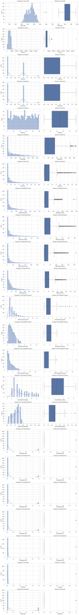

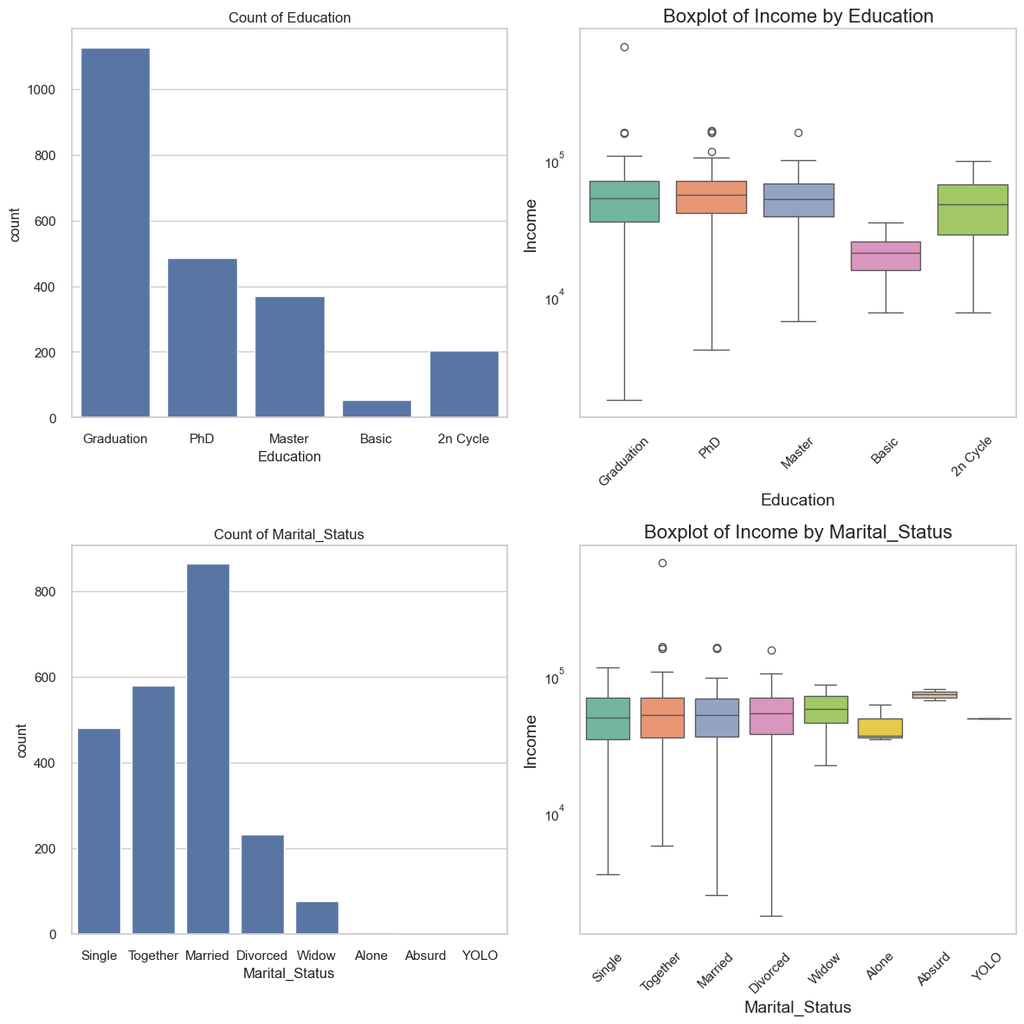

```python
# Set the aesthetics for the plots
sns.set(style="whitegrid")

# Plots for numerical variables
num_cols = df.select_dtypes(include=[np.number]).columns
num_cols = num_cols.drop('ID').drop('Z_CostContact').drop('Z_Revenue') # exclude irrelevant features
num_plots = len(num_cols)

# Set up the figure and axes for histograms and boxplots
fig, axes = plt.subplots(num_plots, 2, figsize=(12, num_plots * 4))

for i, col in enumerate(num_cols):
    # Histogram
    sns.histplot(df[col], bins=30, kde=True, ax=axes[i, 0])
    axes[i, 0].set_title(f'Histogram of {col}')

    # Boxplot
    sns.boxplot(x=df[col], ax=axes[i, 1])
    axes[i, 1].set_title(f'Boxplot of {col}')

plt.tight_layout()
plt.show()

# Plots for categorical variables
cat_cols = ['Education', 'Marital_Status']
num_cat_plots = len(cat_cols)

# Set up the figure for count plots and boxplots
fig, axes = plt.subplots(num_cat_plots, 2, figsize=(12, num_cat_plots * 6))  # Create subplots for categorical variables

for i, col in enumerate(cat_cols):
    # Count plot
    sns.countplot(x=df[col], ax=axes[i, 0])
    axes[i, 0].set_title(f'Count of {col}')

    # Boxplot
    sns.boxplot(x=df[col], y='Income', data=df, palette='Set2', ax=axes[i, 1])
    axes[i, 1].set_title(f'Boxplot of Income by {col}', fontsize=16)  # Increase title font size
    axes[i, 1].set_xlabel(col, fontsize=14)  # Increase x-axis label font size
    axes[i, 1].set_ylabel('Income', fontsize=14)  # Increase y-axis label font size
    axes[i, 1].set_xticklabels(axes[i, 1].get_xticklabels(), rotation=45)  # Rotate x-axis labels for better visibility
    axes[i, 1].set_yscale('log')  # Use logarithmic scale to improve readability of y-axis
    axes[i, 1].grid(axis='y')  # Add grid lines for better readability

plt.tight_layout()
plt.show()
```

##### **Observations:**

Numerical Variables

Categorical Variables:

### Bivariate Analysis

#### **Question 6:** Perform multivariate analysis to explore the relationsips between the variables.

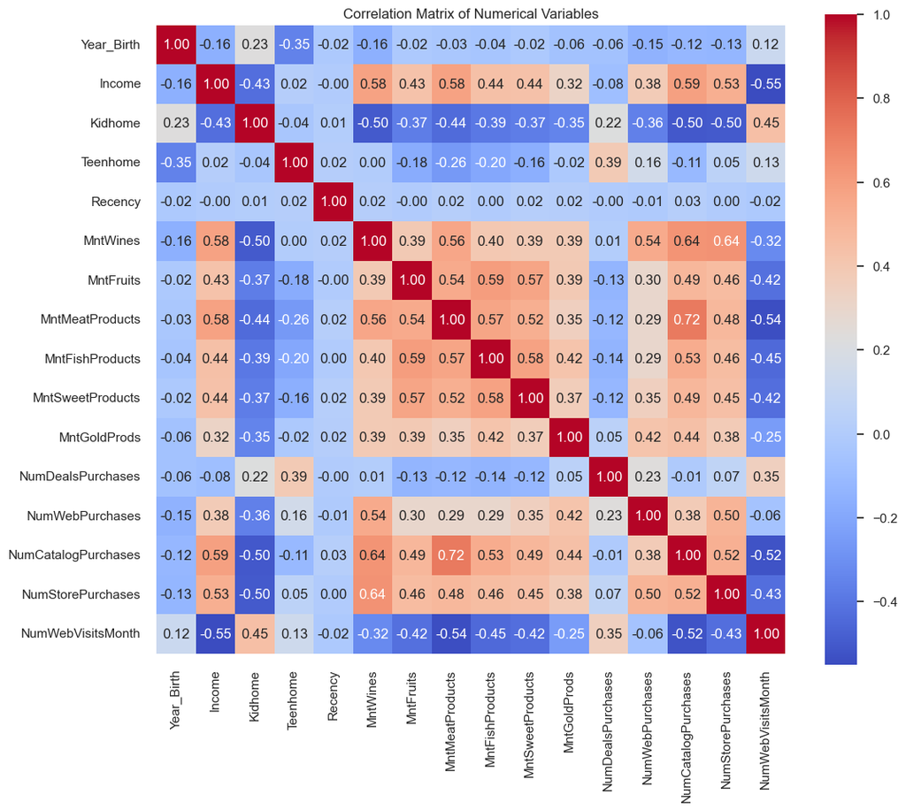

```python
# Calculate the correlation matrix for numerical columns
# for simplicity, only categorical variables are considered
num_cols = df.select_dtypes(include=[np.number]).columns

# exclude ID as it is a static field
# exclude features which are irrelevant or have low volume of data
num_cols = num_cols.drop(['ID', 'Z_CostContact', 'Z_Revenue', 'Complain', 'Response'], errors='ignore')

num_cols = [col for col in num_cols if 'AcceptedCmp' not in col]
correlation_matrix = df[num_cols].corr()

plt.figure(figsize=(12, 10))

sns.heatmap(correlation_matrix, annot=True, fmt=".2f", cmap='coolwarm', square=True)
plt.title('Correlation Matrix of Numerical Variables')
plt.show()
```

##### **Observations:**

1. Strong +ve correlation:
   - Income vs MntWine or MntMeat (0.58): Higher income implies more wine and meat purchases
   - Income vs NumCatalogPurchases (0.59) or MntStorePurchases (0.53): Higher income implies more catalog and store purchases.
   - MntWines vs MntMeat (0.56): Customers who spend more on wines also tend to spend more on meat.
   - MntCataglogPurchases vs MntWines (0.64): more catalogue purchases mean more wines purchases.
   - MntStorePurchases vs MntWines (0.64): more store purchases mean more wines purchases.
   - MntFruits vs MntMeat (0.54) or MntFishProducts (0.59) or MntSweetProducts (0.57): Customers who spend more on fruits also tend to spend more on meat, fish products or sweet products.
2. Moderate +ve correlation:
   - Kidhome vs NumWebVisitsMonth (0.45): Customers with kid(s) tend to have more visits of the retail company website.
3. Weak +ve correlation:
   - Year_Birth: there is no obvious correlation with other features because of low correlation values.
   - Teenhome, Recency: similar to Year_Birth
   - NumWebVisitsMonth vs NumDealsPurchases (0.35): customers tend to have more online purchases with discounts.
   - NumDealPurchases vs Teenhome (0.39) or NumWebVisitsMonth (0.35): Purchases with discount implies customers may have a teen and more web visits.

## **K-means Clustering**

#### **Question 7** : Select the appropriate number of clusters using the elbow Plot. What do you think is the appropriate number of clusters?

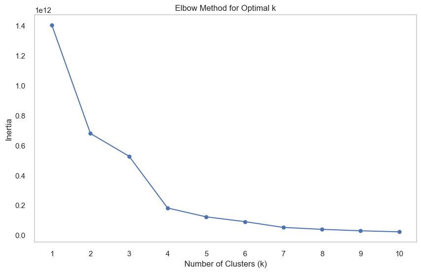

```python
# Determine the optimal number of clusters using the elbow method
inertia = []
k_values = range(1, 11)

# for simplicity, only consider numerical data
numerical_data = df.select_dtypes(include=[np.number]).drop(columns=['ID'])

for k in k_values:
    kmeans = KMeans(n_clusters=k, random_state=42)
    kmeans.fit(numerical_data)
    inertia.append(kmeans.inertia_)

# Plot the elbow curve
plt.figure(figsize=(10, 6))
plt.plot(k_values, inertia, marker='o')
plt.title("Elbow Method for Optimal k")
plt.xlabel("Number of Clusters (k)")
plt.ylabel("Inertia")
plt.xticks(k_values)
plt.grid()
plt.show()
```

##### **Observations:**

1. The intertia starts to descrease slowly at K = 4.
2. This suggests that using 4 clusters captures the variations in the data effectively without overfitting.

#### **Question 8** : finalize appropriate number of clusters by checking the silhoutte score as well. Is the answer different from the elbow plot?

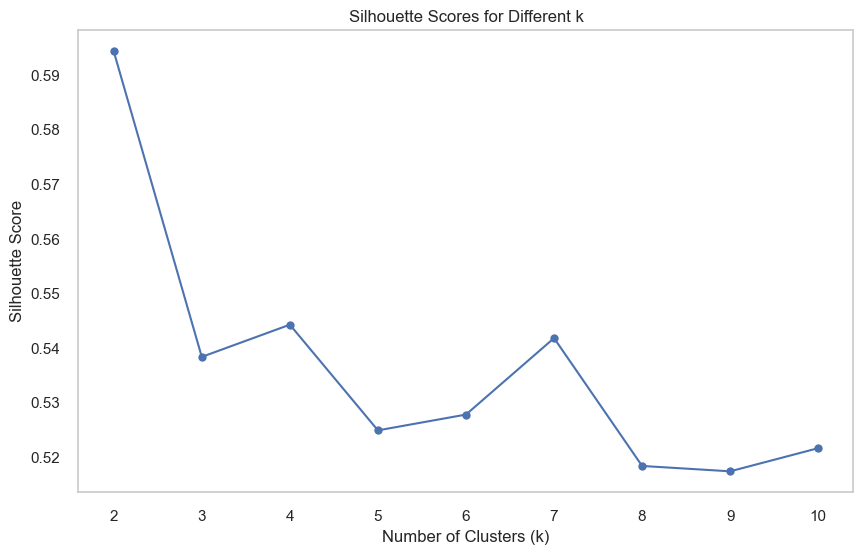

```python
silhouette_scores = []

for k in range(2, 11):
    kmeans = KMeans(n_clusters=k, random_state=42)
    kmeans_labels = kmeans.fit_predict(numerical_data)
    silhouette_scores.append(silhouette_score(numerical_data, kmeans_labels))

# Plot silhouette scores
plt.figure(figsize=(10, 6))
plt.plot(range(2, 11), silhouette_scores, marker='o')
plt.title("Silhouette Scores for Different k")
plt.xlabel("Number of Clusters (k)")
plt.ylabel("Silhouette Score")
plt.xticks(range(2, 11))
plt.grid()
plt.show()
```

##### **Observations:**

1. The silhouette score starts at the highest value with 2 clusters. Then it drops sharply while approaching 3, suggesting an additional cluster does not provide better clustering.
2. Best no. of clusters is 2 by silhouette score.

#### **Question 9**: Do a final fit with the appropriate number of clusters. How much total time does it take for the model to fit the data?

```python
# 3-cluster is chosen as it is a good balance between cluster separation and compactness
# For marketing purpose, well-separated cluster 2 clusters more better for actionable insights.
# So 2-cluster is not chosen as it may oversimplify the clustering.
optimal_k = 3

# Fit the model and measure time
start_time = time.time()
kmeans_final = KMeans(n_clusters=optimal_k, random_state=42)
kmeans_final.fit(numerical_data)
end_time = time.time()

# Calculate total time taken
total_time = end_time - start_time
print(f"Total time taken for the KMeans model to fit the data: {total_time:.4f} seconds")
```

```
Total time taken for the KMeans model to fit the data: 0.0335 seconds
```

##### **Observations:**

The calculated fitting time suggests that the KMeans algorithm executed efficiently for small to medium-sized datasets. This facilitates real-time clustering.

## **Hierarchical Clustering**

#### **Question 10**: Calculate the cophnetic correlation for every combination of distance metrics and linkage. Which combination has the highest cophnetic correlation?

```python
# Define distance metrics and linkage methods
distance_metrics = ['euclidean', 'cityblock', 'cosine']
linkage_methods = ['single', 'complete', 'average', 'ward']

# Initialize results list
results = []

# Calculate cophenetic correlation for specified combinations
for metric in distance_metrics:
    for method in linkage_methods:
        # Skip incompatible combinations
        if method == 'ward' and metric != 'euclidean':
            continue

        # Calculate the linkage matrix
        Z = linkage(numerical_data, method=method, metric=metric)

        # Calculate the cophenetic distance
        coph_dist, _ = cophenet(Z, pdist(numerical_data, metric=metric))

        # Store results
        results.append((metric, method, coph_dist))

# Convert results to DataFrame for easier analysis
results_df = pd.DataFrame(results, columns=['Distance Metric', 'Linkage Method', 'Cophenetic Correlation'])

# Find the combination with the highest cophenetic correlation
highest_coph_corr = results_df.loc[results_df['Cophenetic Correlation'].idxmax()]

print("Combination with the highest cophenetic correlation:")
print(highest_coph_corr)
```

```
Combination with the highest cophenetic correlation:
Distance Metric             cosine
Linkage Method             average
Cophenetic Correlation    0.957899
Name: 9, dtype: object
```

#### **Question 11**: plot the dendogram for every linkage method with "Euclidean" distance only. What should be the appropriate linkage according to the plot?

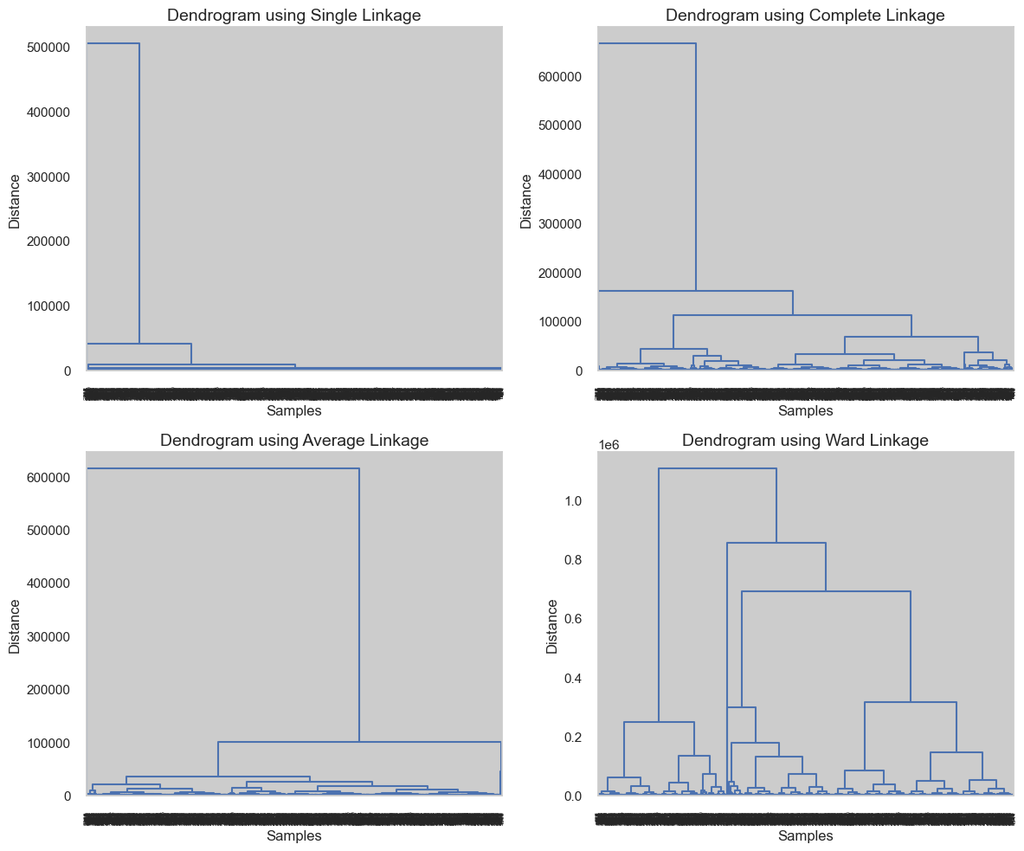

```python
Z_single = linkage(numerical_data, method='single')
Z_complete = linkage(numerical_data, method='complete')
Z_average = linkage(numerical_data, method='average')
Z_ward = linkage(numerical_data, method='ward')

fig, axes = plt.subplots(2, 2, figsize=(12, 10))

# Create dendrograms
dendrogram(Z_single, ax=axes[0, 0], color_threshold=0)
axes[0, 0].set_title('Dendrogram using Single Linkage', fontsize=14)
axes[0, 0].set_xlabel('Samples', fontsize=12)
axes[0, 0].set_ylabel('Distance', fontsize=12)
axes[0, 0].grid(axis='y')

dendrogram(Z_complete, ax=axes[0, 1], color_threshold=0)
axes[0, 1].set_title('Dendrogram using Complete Linkage', fontsize=14)
axes[0, 1].set_xlabel('Samples', fontsize=12)
axes[0, 1].set_ylabel('Distance', fontsize=12)
axes[0, 1].grid(axis='y')

dendrogram(Z_average, ax=axes[1, 0], color_threshold=0)
axes[1, 0].set_title('Dendrogram using Average Linkage', fontsize=14)
axes[1, 0].set_xlabel('Samples', fontsize=12)
axes[1, 0].set_ylabel('Distance', fontsize=12)
axes[1, 0].grid(axis='y')

dendrogram(Z_ward, ax=axes[1, 1], color_threshold=0)
axes[1, 1].set_title('Dendrogram using Ward Linkage', fontsize=14)
axes[1, 1].set_xlabel('Samples', fontsize=12)
axes[1, 1].set_ylabel('Distance', fontsize=12)
axes[1, 1].grid(axis='y')

# Adjust line thickness after creating the dendrogram
for ax in axes.flat:
    for line in ax.get_lines():
        line.set_linewidth(1.5)  # Set a new line width

plt.tight_layout()
plt.show()
```

##### **Observations:**

1. Single Linkage: Tends to produce long, thin clusters. Look for "chaining" effects where clusters may merge based on a few close points.
2. Complete Linkage: Typically results in more compact clusters. It may create a more balanced dendrogram, where clusters are more evenly sized.
3. Average Linkage: Balances the characteristics of both single and complete linkage. It may give a good representation of the data structure.
4. Ward's Method: Aims to minimize the variance within clusters. It often results in well-separated clusters and is generally effective for most datasets.

#### **Question 12:** Check the silhoutte score for the hierchial clustering. What should be the appropriate number of clusters according to this plot?

```python
# Define the range of clusters
range_n_clusters = range(2, 11)  # e.g., from 2 to 10 clusters

# Calculate silhouette scores for each number of clusters
silhouette_avg_list = []

for n_clusters in range_n_clusters:
    # Start the timer
    start_time = time.time()

    # Perform hierarchical clustering
    clusterer = AgglomerativeClustering(n_clusters=n_clusters, metric='euclidean', linkage='ward')
    cluster_labels = clusterer.fit_predict(numerical_data)

    # Stop the timer
    end_time = time.time()

    # Calculate the time taken
    time_taken = end_time - start_time
    silhouette_avg = silhouette_score(numerical_data, cluster_labels)

    print(f'For n_clusters = {n_clusters}, the average silhouette score is: {silhouette_avg:.4f}')
    print(f'Time taken to fit the model: {time_taken:.4f} seconds\n')
```

```
For n_clusters = 2, the average silhouette score is: 0.5119
Time taken to fit the model: 0.2549 seconds

For n_clusters = 3, the average silhouette score is: 0.5188
Time taken to fit the model: 0.2341 seconds

For n_clusters = 4, the average silhouette score is: 0.5319
Time taken to fit the model: 0.2366 seconds

For n_clusters = 5, the average silhouette score is: 0.4836
Time taken to fit the model: 0.2359 seconds

For n_clusters = 6, the average silhouette score is: 0.4995
Time taken to fit the model: 0.2313 seconds

For n_clusters = 7, the average silhouette score is: 0.4823
Time taken to fit the model: 0.2271 seconds

For n_clusters = 8, the average silhouette score is: 0.4758
Time taken to fit the model: 0.2167 seconds

For n_clusters = 9, the average silhouette score is: 0.4912
Time taken to fit the model: 0.2200 seconds

For n_clusters = 10, the average silhouette score is: 0.4957
Time taken to fit the model: 0.2358 seconds
```

#### **Question 13**: Fit the Hierarchial clustering model with the appropriate parameters finalized above. How much time does it take to fit the model?

```python
n_clusters = 3
linkage_method = 'ward'  # Use 'ward' for minimizing variance

# Start the timer
start_time = time.time()

# Fit the hierarchical clustering model
clusterer = AgglomerativeClustering(n_clusters=n_clusters, metric='euclidean', linkage='ward')
cluster_labels = clusterer.fit_predict(numerical_data)

numerical_data['Hierarchical_Labels'] = cluster_labels

# Stop the timer
end_time = time.time()

# Calculate the time taken
time_taken = end_time - start_time
print(f'Time taken to fit the model: {time_taken:.4f} seconds')
```

```
Time taken to fit the model: 0.2313 seconds
```

##### **Observations:**

The calculated fitting time suggests that the model is efficient for the given dataset.

## **Cluster Profiling and Comparison**

### K-Means Clustering vs Hierarchical Clustering Comparison

#### **Question 14**: Perform and compare Cluster profiling on both algorithms using boxplots. Based on the all the observaions Which one of them provides better clustering?

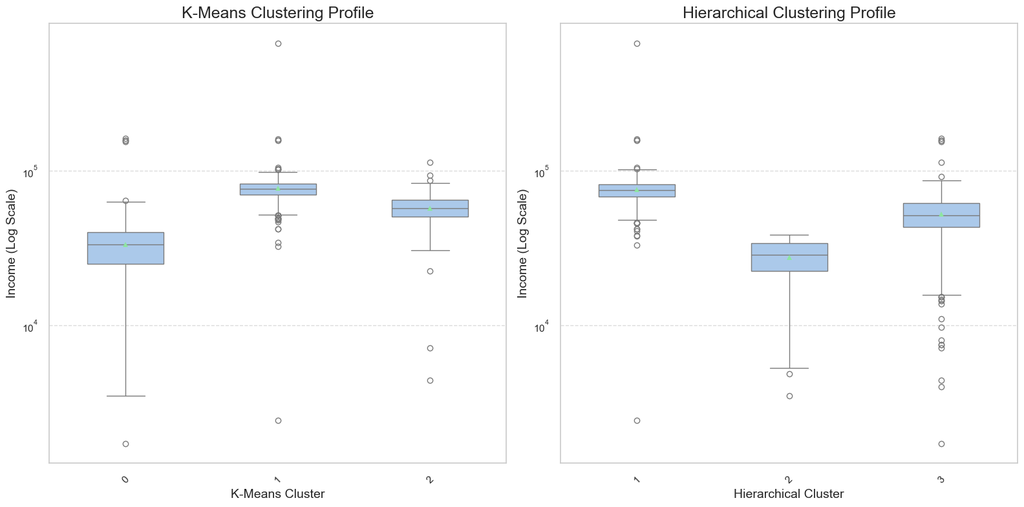

```python
cluster_count = 3
sns.set(style="whitegrid", palette="pastel")

# Scale the numerical features
scaler = StandardScaler()
scaled_data = scaler.fit_transform(numerical_data.select_dtypes(include=[np.number]))

# K-Means Clustering
kmeans = KMeans(n_clusters=cluster_count, random_state=42)
numerical_data['KMeans_Cluster'] = kmeans.fit_predict(scaled_data)

# Hierarchical Clustering
linkage_matrix = linkage(scaled_data, method='ward')
numerical_data['Hierarchical_Cluster'] = fcluster(linkage_matrix, t=cluster_count, criterion='maxclust')

# Create a figure with two subplots side by side
fig, axes = plt.subplots(1, 2, figsize=(16, 8))

# Boxplot for K-Means Clusters
sns.boxplot(x='KMeans_Cluster', y='Income', data=numerical_data, showmeans=True, width=0.5, ax=axes[0])
axes[0].set_title('K-Means Clustering Profile', fontsize=18)
axes[0].set_xlabel('K-Means Cluster', fontsize=14)
axes[0].set_ylabel('Income (Log Scale)', fontsize=14)
axes[0].set_yscale('log')  # Set y-axis to logarithmic scale
axes[0].grid(axis='y', linestyle='--', alpha=0.7)
axes[0].tick_params(axis='x', rotation=45)

# Boxplot for Hierarchical Clusters
sns.boxplot(x='Hierarchical_Cluster', y='Income', data=numerical_data, showmeans=True, width=0.5, ax=axes[1])
axes[1].set_title('Hierarchical Clustering Profile', fontsize=18)
axes[1].set_xlabel('Hierarchical Cluster', fontsize=14)
axes[1].set_ylabel('Income (Log Scale)', fontsize=14)
axes[1].set_yscale('log')  # Set y-axis to logarithmic scale
axes[1].grid(axis='y', linestyle='--', alpha=0.7)
axes[1].tick_params(axis='x', rotation=45)

# Adjust layout to prevent overlap
plt.tight_layout()
plt.show()
```

##### **Observations:**

K-Means Cluster:

- Each cluster has distinct median income values, indicating clear segmentation. The median values vary significantly across different clusters.
- The IQRs varies among clusters.
- There are noticeable outliers in some clusters, which may indicate that K-Means is less effective in capturing the underlying structure of the data for those segments.

Hiearchical Cluster:

- Similar to K-Means, the median incomes are different across the clusters.
- The IQRs also varies among clusters.
- Outliers looks more than K-Means.

**Conclusion:** Since K-Means Cluster has fewer outliers, it can conclude that it captures the data structure more effectively. Therefore, K-Means provides better clustering in this case.

#### **Question 15**: Perform Cluster profiling on the data with the appropriate algorithm determined above using a barplot. What observations can be derived for each cluster from this plot?

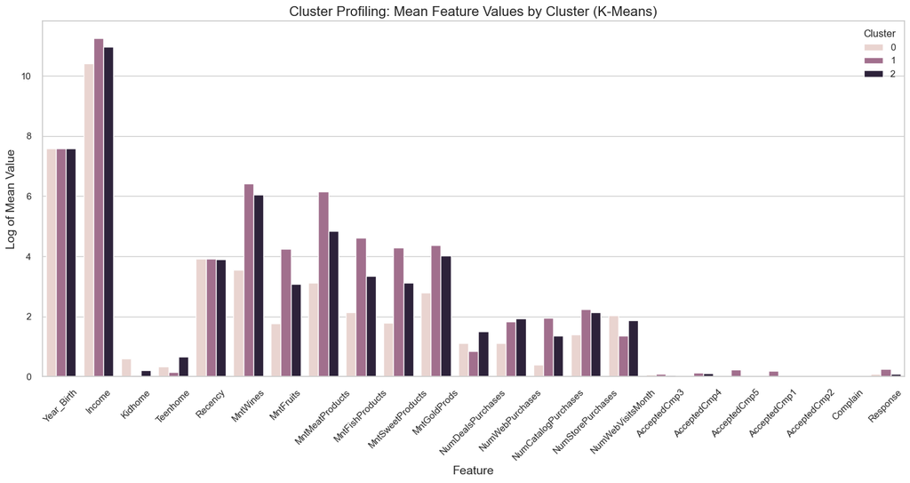

```python
# Identify features to remove
features_to_remove = [col for col in numerical_data.columns if '_Label' in col or col.startswith('Z_') or col == 'Hierarchical_Cluster']
filtered_numerical_data = numerical_data.drop(columns=features_to_remove)

# Calculate the means for each cluster
cluster_means = filtered_numerical_data.groupby('KMeans_Cluster').mean().reset_index()

# Melt the DataFrame for easier plotting
cluster_means_melted = cluster_means.melt(id_vars='KMeans_Cluster',
                                            var_name='Feature',
                                            value_name='Mean')

# Apply log transformation for better visualization
cluster_means_melted['Mean'] = np.log1p(cluster_means_melted['Mean'])  # log(1 + x)

# Create the barplot
sns.set(style="whitegrid")
plt.figure(figsize=(15, 8))
sns.barplot(x='Feature', y='Mean', hue='KMeans_Cluster', data=cluster_means_melted)
plt.xticks(rotation=45)
plt.title('Cluster Profiling: Mean Feature Values by Cluster (K-Means)', fontsize=16)
plt.ylabel('Log of Mean Value', fontsize=14)
plt.xlabel('Feature', fontsize=14)
plt.legend(title='Cluster')
plt.tight_layout()
plt.show()
```

##### **Business Recommedations:**

1. Strengthen the sales of key products by offering more diversified product brands, cross-selling discounts across different key products.
2. Offer more high priced wines and meats to attract medium and high-income clusters.
3. Offer more ad-hoc or seasonal discount sales for key products to boost up web purchases.
4. Offer some products with special discounts/limit-time offers for web purchases. This may encourage more web purchases from low-income customers.
5. Strengthen catalog sales by providing convenient channels, product catalog, etc.
6. Review and improve web site or app in order to attract more web visits.
7. Launch more marketing events to attract more customer response rate, or evalualte the accessibility of response channels.
8. While the complaint rate is low, it may be better to provide channels of customer feedback. Display customer feedbacks in retail stores. This may improve customer experiences and loyalty.
9. While gold products are high worth products, strengthen the sales by offering more product types and discounts.
10. Offer some products trageting kids or teens.